# Question 1

# Question 2

In this question, we consider the marketing dataset from datarium package in R.

The data contains 200 observations and 4 variables. The response variable is sales, de-noted as Y . The explanatory variables|measured in thousands of dollars|are advertising budget spent on youtube, newspapers and facebook, respectively, which are denoted as X1;X2 and X3, respectively.

To model the impact of the three media on sales, a researcher uses the following multiple linear regression:

$Y=\beta_{0}+\beta_{1} X_{1}+\beta_{2} X_{2}+\beta_{3} X_{3}+\epsilon$ (1) $=\mathrm{X} \beta+\epsilon$ (2)

where $Y;X1;X2$ and $X3$ is a vector of $n / 1$ (n is the number of observations in the dataset), $X = (1n;X1;X2;X3)$ and

$\beta=\left[\beta_{0}, \beta_{1}, \beta_{2}, \beta_{3}\right]^{\prime}$

The parameter $\beta$ in Equation (2) and its standard deviation. $s.d()$ can be estimated by using the function $lm()$ in $R$. Alternatively, $\beta$ can be estimated by minimising the following loss function - mean squared errors:

$\mathcal{L}=\frac{1}{n}(Y-\mathbf{X} \boldsymbol{\beta})^{\prime}(Y-\mathbf{X} \boldsymbol{\beta})=\frac{1}{n} \sum_{i=1}^{n}\left(Y_{i}-\mathbf{X}_{i} \boldsymbol{\beta}\right)^{2}$ (3)

It is well-known that the optimal solution of $\beta$ in Equation (3), denoted as $\hat{\beta}$ has the following form:

$\hat{\beta}=\left(\mathbf{X}^{\prime} \mathbf{X}\right)^{-1} \mathbf{X}^{\prime} Y$ (4)

and its standard deviation is:

$s.d(\hat{\boldsymbol{\beta}})=\sqrt{s^{2}\left(\mathrm{X}^{\prime} \mathbf{X}\right)^{-1}} \text {where } s^{2}=\frac{1}{n-4} \sum_{i=1}^{n}\left(Y_{i}-\mathbf{X}_{i} \hat{\boldsymbol{\beta}}\right)^{2}, i=1,2, \ldots, n$ (5)

### 2(a) - Write a program in R to estimate and its standard deviation using equations (4) and (5).

```r
library(pracma)
library(datarium)

# import data set
data(marketing)
class(marketing)
```

```
## [1] "data.frame"
```

```r
#head
head(marketing)
```

```
##   youtube facebook newspaper sales
## 1     276       45        83  26.5
## 2      53       47        54  12.5
## 3      21       55        83  11.2
## 4     182       50        70  22.2
## 5     217       13        70  15.5
## 6      10       59        90   8.6
```

Plot the data and explore relationships

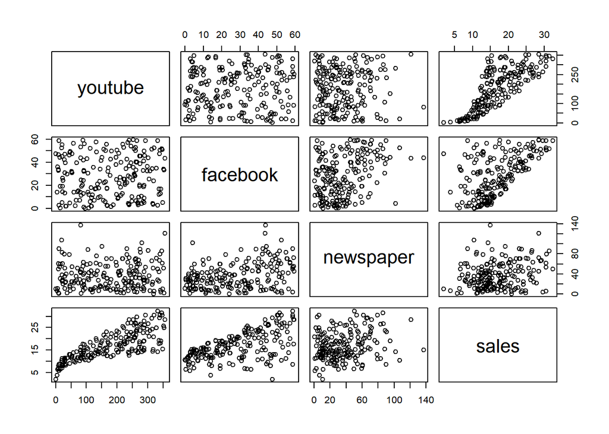

```r
plot(marketing)
```

Build the multiple linear regression model

```r
# Build the multiple linear regression model
# Create response and explanatory variables

n = length(marketing$sales)
y = marketing$sales
youtube <- marketing$youtube
facebook <- marketing$facebook
newspaper <- marketing$newspaper


# Create design matrix

x = cbind(Intercept = 1,youtube,facebook,newspaper)

# Using equation (4) on task sheet - coefficient estimates


B_hat = (solve(t(x)%*%x))%*%(t(x)%*%y)
B_hat
```

```
##             [,1]
## Intercept  3.527
## youtube    0.046
## facebook   0.189
## newspaper -0.001
```

```r
# Using equation (5) Calculate s2 so that std error cal be calculated

s2 = sum((y - x%*%B_hat)^2)/(nrow(x)-ncol(x))

# Covariance-Variance Matrix - diagonal represents the variance of each coefficient

covar <- s2*inv((t(x)%*%x))
d = diag(covar)

# Coefficient estimate of standard errors/standard deviation (square root diagonal elements of the covariance matrix)

st_error = sqrt(diag(covar))

# use LM function for linear modelling and comparison between manual calculation

lm <- lm(sales ~., data = marketing)

# std.error for comparison

lm_se <- sqrt(diag(vcov(lm)))
```

### 2(b) - Compare the results obtained in Question 2(a) with those obtained from the function $lm()$.

Results between the two methods are identical

```r
# create comparison table

comparison_df <- cbind(B_hat, lm$coefficients, st_error, lm_se)
colnames(comparison_df) <- c("manual coefficients", "lm coefficients", "manual st_error", "lm Std. Error")
comparison_df
```

```
##           manual coefficients lm coefficients manual st_error lm Std. Error
## Intercept               3.527           3.527          0.3743        0.3743
## youtube                 0.046           0.046          0.0014        0.0014
## facebook                0.189           0.189          0.0086        0.0086
## newspaper              -0.001          -0.001          0.0059        0.0059
```

# Question 3

### (a) - Another approach to estimate $\beta$ in Equation (3) is to use Classical Gradient Descent.

### Deciding what loss function to use.

There are several options which are available and its important to understand whether your ML model is attempting to perform predictions based on regression or classification. As we are modelling linear regression MSE will be used as part of the loss function.

The loss function can be represented as $J_{m, b}=\frac{1}{N} \sum_{i=1}^{N}\left(Y_{i}^{\prime}-Y_{i}\right)^{2}$ with $m$ and $b$ being the functions parameters. The aim of gradient descent is to find the values of m and b where the error is the lowest.

### Calculating the derivative of the loss function

We will compute the derivative of this function so that we are able to find the minimum of the function i.e the local minima. Gradient descent uses derivatives to decide whether to increase or decrease the weights in order to increase or decrease the objective function

## Procedure

There are 4 main steps in calculating classical gradient descent.

**Step 1 - set starting point**

$x^{(k)},$ set $k=0$

This is the starting point for the algorithm and can be an arbitrary number. This specific model starts as 0.

**Step 2 - Compute gradient of the loss with respect to parameters (variables in x)**

This can be represented as $\nabla f\left(x^{(k)}\right)$ and is the derivative of the loss function

**step 3 - Move parameters away from the gradient**

This can be represented as $x^{(k+1)}=x^{(k)}-\alpha_{k} \nabla f\left(x^{(k)}\right)$ where $\alpha_{k}$ is the learning rate/step of the function.

**step 4 - Iterate**

set $k=k+1$ and repeat a large number of times.

## (b) Write an R code to implement the Classical Gradient Descent procedure provided in Question 3(a).

```r
gd.lm<-function(x, y, alpha = 0.00002, max.iter=150000, changes=0.01){
  start_time <- Sys.time()
  print("Initialising")

  # Initialise matrices for storing gradient and coefficients

  # Coefficients

  p <- matrix(0, nrow=max.iter, ncol=ncol(x))

  # Gradients

  gradient <-matrix(0, nrow=max.iter, ncol=ncol(x))

  # Step 1

  # Set starting point in matrix

  p[1,] <- p[1,]<-rep(0,4)

  # Calculate gradient descent

  print("Processing")
  for( i in 1:(max.iter-1)){

    # Update yhat with data from Gradient Descent approximation formula calculation

    yhat = p[i,1] + p[i,2]*x[,2] + p[i,3]*x[,3] + p[i,4]*x[,4]

    # Step 2

    # Use product rule to calculate derivative of loss function (MSE) of coefficients & intercept

    gradient[i,1]<--2*mean(y-yhat)
    gradient[i,2]<--2*mean(x[,2]*(y-yhat))
    gradient[i,3]<--2*mean(x[,3]*(y-yhat))
    gradient[i,4]<--2*mean(x[,4]*(y-yhat))

    # Step 3 & 4 Gradient Descent approximation formula

    p[i+1,1]<-p[i,1]-alpha*gradient[i,1]
    p[i+1,2]<-p[i,2]-alpha*gradient[i,2]
    p[i+1,3]<-p[i,3]-alpha*gradient[i,3]
    p[i+1,4]<-p[i,4]-alpha*gradient[i,4]

    # Exit loop logic

    if(i > 1 & all(abs(gradient[i,]) < changes)){
      i=i-1
      break;
    }
  }

  # Processing time

  end_time <- Sys.time()
  pt <- end_time - start_time
  cat("Processed in", pt )

  # Return from function with results of the iterator, coefficient matrix and gradient matrix in list

  return(list("i"=i, "p"=p, "g"=gradient))
}
```

### Running the model

There are 5 arguments which can be passed into the function:

**x** = matrix with intercept **y** = target variable vector with length = x **max.iter** = number of iterations to complete **alpha** = learning rate **changes** = threshold cost value to exit the loop

$gd.lm(x, y, max.iter = 800000, alpha = 0.00002, changes = 0.01)$

```r
l <- gd.lm(x, y, max.iter = 800000, alpha = 0.00002)
```

```
## [1] "Initialising"
## [1] "Processing"
## Processed in 32
```

```r
# Add coefficients to existing comparison table

grad_desc <- data.frame(l$p[l$i,])
colnames(grad_desc) <- c("gd_coefficients")
comparison_df <- cbind(comparison_df, grad_desc)
comparison_df <- comparison_df[, c(1, 2, 5, 3, 4)]
```

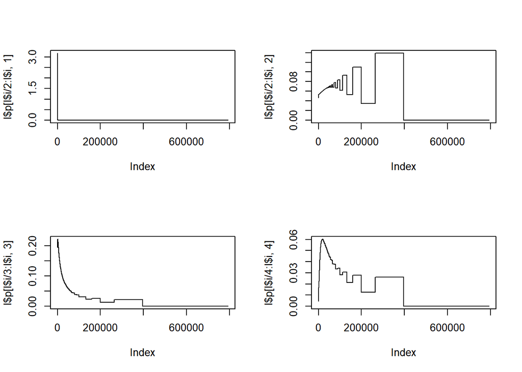

```r
# plot results

par(mfrow=c(2,2))
plot(l$p[l$i/2:l$i,1], type='l')
plot(l$p[l$i/2:l$i,2], type='l')
plot(l$p[l$i/3:l$i,3], type='l')
plot(l$p[l$i/4:l$i,4], type='l')
```

### (c) Compare the estimate of $\beta$ obtained in Question 3(b) with that obtained in Question 2(a). Provide some explanations if the results are similar or different.

As you can see in the comparison table below the results between the lm(), manual coefficient calculation using $\hat{\beta}=\left(\mathbf{X}^{\prime} \mathbf{X}\right)^{-1} \mathbf{X}^{\prime} Y$ and the gradient descent method using $x^{(k+1)}=x^{(k)}-\alpha_{k} \nabla f\left(x^{(k)}\right)$ are all very similar. More time could be spent on refining the learning rate and the number of iterations when calling the gradient descent function. This function is sensitive to these arguments however this is likely to have an impact on the performance of the function.

```r
comparison_df
```

```
##           manual coefficients lm coefficients gd_coefficients manual st_error
## Intercept               3.527           3.527         3.49242          0.3743
## youtube                 0.046           0.046         0.04584          0.0014
## facebook                0.189           0.189         0.18886          0.0086
## newspaper              -0.001          -0.001        -0.00086          0.0059
##           lm Std. Error
## Intercept        0.3743
## youtube          0.0014
## facebook         0.0086
## newspaper        0.0059
```

# Question 4

### Compare the optimisation algorithms of Classical Gradient Descent, Stochastic Gradient Descent and Newton’s methods to see advantages and disadvantages of each algorithm.

### Classical Gradient Descent (CGD)

Gradient descent is a broadly used first order optimisation technique which determines a local minima for a differentiable function. i.e it uses derivatives to decide whether to increase or decrease the weights in order to increase or decrease the objective function.

It is an iterative process which is repeated until convergence which can be represented as:

$x^{(k+1)}=x^{(k)}-\alpha_{k} \nabla f\left(x^{(k)}\right)$

where $\alpha_{k}$ is the learning rate/step of the function.

It starts at a random point on the function and using the formula above will take steps until it reaches the lowest point of the function i.e the local minima.

There is somewhat of a challenge when executing the gradient descent function(s) as they are sensitive to the learning rate. If your learning rate is too low the model will be inefficient and slow as each step is too small. Conversely if the learning rate is too high it can cause divergence in within the loss function

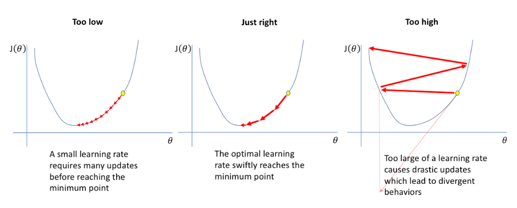

**Advantages**

- High degree of accuracy
- Simple model to use and only uses first order derivatives

**Disadvantages**

- Convergence rate is slow
- Model is inefficient and redundant computation is executed

### Stochastic Gradient Descent (SGD)

Stochastic gradient descent is a version of classic gradient descent in which random samples for each iteration are selected. Once the sample is selected then only it is used as part of the Gradient Descent approximation formula as opposed to all samples as in CGD.

There are also sub types of SGD in which mini batching or sub sampling at each iteration is used.

**Advantages**

- Much faster performance compared with CGD
- No redundant computation

**Disadvantages**

- Model is less accurate than CGD
- The steps taken towards the minima are inconsistent and can lead to the gradient descent into other directions.

### Newton’s Method

Newtons method is an optimisaion technique that uses a second order polynomial method that uses first and second differentiation of a function to determine optimisation.

The Hessian matrix is a square matrix of second order partial derivatives of a scalar function with respect to $x_{1}, x_{2}, \dots, x_{n}$. Newtons method is calculated by replacing the learning rate by the inverse of the Hessian matrix and can be represented as $x^{(k+1)}=x^{(k)}-F\left(x^{(k)}\right)^{-1} \nabla f\left(x^{(k)}\right)$

The main difference between CGD and Newton’s is that Newtons is a root finding algorithm and it maximises a function using its second derivative (Hessian Matrix).

**Advantages**

- Quadratic approach to convergence. If the initial point is close to the minimum, then convergence will occur much faster than classical gradient descent.

**Disadvantages**

- Not guaranteed that Newton’s method will converge if the selected starting point is too far from the exact root.
- Requires a lot of computer resources to process